# MCBD survey 3 Cleanup and Summaries

Veronica F. Frans, CSIS Lab, Michigan State University

May 30, 2020 (Updated: September 4, 2020)

# 1. Methods summary

Synthesis of survey 3 results for metacoupling/biodiversity systematic review. It consists of error checks, response summaries, and visualizations of the accepted papers.

# 2. R Setup

The script presented here was done using R (version 4.0.2; R Core Team 2020) and its packages.

Load libraries, directories, and custom functions from source file.

```r
# Source file
  source('Reference.R')
```

Data is stored here:

```
## [1] "C:/Users/niqui/OneDrive - Michigan State University/My Projects/Biodiv_Metacoupling/MCBD_Root/MCBD/data/"
```

Final tables are stored here:

```
## [1] "C:/Users/niqui/OneDrive - Michigan State University/My Projects/Biodiv_Metacoupling/MCBD_Root/MCBD/results/"
```

Final figures are stored here:

```
## [1] "C:/Users/niqui/OneDrive - Michigan State University/My Projects/Biodiv_Metacoupling/MCBD_Root/MCBD/images/"
```

For **this run** of the script, tables for manual checks will be stored in the following folder:

```
## [1] "C:/Users/niqui/OneDrive - Michigan State University/My Projects/Biodiv_Metacoupling/MCBD_Root/MCBD/issues/2020-09-04/"
```

# 3. Load data

```r
# load previous workspace (if needed)
  #load("survey3Results.RData")

# survey
  survey3 <- read.csv(paste0(dat.dir,'survey_cleanup\\survey3_for_cleanup.csv'))

# 5 common surveys
  survey3.5 <- read.csv(paste0(dat.dir,
                       'common_papers\\survey3_5_common_paper_selection_090120.csv'))
```

# 4. Data cleanup

## 4.1 Data preview

Merge survey 3 with the 5 common paper survey result (note that the structures have to match).

```r
# drop columns
  survey3.5 <- subset(survey3.5,
                      select=-c(entry,final_decision))

# change structure
  survey3.5$entry_id <- as.character(survey3.5$entry_id)
  survey3.5$p_value <- as.character(survey3.5$p_value)

# bind rows
  survey3 <- bind_rows(survey3,survey3.5)
```

Quick summary of the dataset.

```r
# number entries
  paste('number of entries:',nrow(survey3))

# number columns
  paste('number of columns:',ncol(survey3))

# column names
  paste('column names:')
  colnames(survey3)

# number of unique papers surveyed
  paste('number of papers:',length(unique(survey3$paper_id)))

# number of observers
  paste('number of observers:',length(unique(survey3$coder_id)))

# list of observers
  paste('observer names:')
  paste(unique(survey3$coder_id),collapse="; ")
```

```
## [1] "number of entries: 796"
## [1] "number of columns: 16"
## [1] "column names:"
##  [1] "timestamp"          "paper_id"           "taxa"
##  [4] "entry_id"           "taxon_or_func"      "biodiv_cat_1sp"
##  [7] "biodiv_cat_multsp"  "biodiv_cat_habitat" "scale"
## [10] "biodiv_temp_res"    "effect"             "significant"
## [13] "p_value"            "notes"              "coder_id"
## [16] "entry"
## [1] "number of papers: 136"
## [1] "number of observers: 11"
## [1] "observer names:"
## [1] "MG_Chung; A_Herzberger; A_Torres; M_Lei; X_Wu; E_Dean; K_Kapsar; Y_Zhang; C_Hovis; E_Xing; Y_Li"
```

The expected number of papers surveyed should be **149**, based on the number of accepted papers in Survey 1 (as of 6/23/2020).

## 4.2 Editing empty fields

### 4.2.1 Paper ID numbers

```r
# check for blank paper ID number fields
  survey3[survey3$paper_id=='',]
  survey3[is.na(survey3$paper_id),]
```

| timestamp | paper_id | taxa | entry_id | taxon_or_func | biodiv_cat_1sp | biodiv_cat_multsp | biodiv_cat_habitat | scale | biodiv_temp_res | effect | significant | p_value | notes | coder_id | entry |
| --- | --- | --- | --- | --- | --- | --- | --- | --- | --- | --- | --- | --- | --- | --- | --- |

| timestamp | paper_id | taxa | entry_id | taxon_or_func | biodiv_cat_1sp | biodiv_cat_multsp | biodiv_cat_habitat | scale | biodiv_temp_res | effect | significant | p_value | notes | coder_id | entry |
| --- | --- | --- | --- | --- | --- | --- | --- | --- | --- | --- | --- | --- | --- | --- | --- |

### 4.2.2 Entry ID numbers

```r
# check for blank entry ID number fields
  survey3[survey3$entry_id=='',]
  survey3[is.na(survey3$entry_id),]
```

| timestamp | paper_id | taxa | entry_id | taxon_or_func | biodiv_cat_1sp | biodiv_cat_multsp | biodiv_cat_habitat | scale | biodiv_temp_res | effect | significant | p_value | notes | coder_id | entry |
| --- | --- | --- | --- | --- | --- | --- | --- | --- | --- | --- | --- | --- | --- | --- | --- |

| timestamp | paper_id | taxa | entry_id | taxon_or_func | biodiv_cat_1sp | biodiv_cat_multsp | biodiv_cat_habitat | scale | biodiv_temp_res | effect | significant | p_value | notes | coder_id | entry |
| --- | --- | --- | --- | --- | --- | --- | --- | --- | --- | --- | --- | --- | --- | --- | --- |

```r
# check structure
  str(survey3$entry_id)
```

```
##  chr [1:796] "1" "1" "2" "3" "4" "1" "2" "3" "4" "5" "1" "1" "1" "2" "3" ...
```

Find the entry IDs that are non-numeric and edit

```r
# extract non-numeric entry IDs
  subset(survey3, !grepl('^\\d+$', survey3$entry_id))
```

|  | timestamp | paper_id | taxa | entry_id | taxon_or_func | biodiv_cat_1sp | biodiv_cat_multsp | biodiv_cat_habitat | scale | biodiv_temp_res | effect | significant | p_value | notes | coder_id | entry |
| --- | --- | --- | --- | --- | --- | --- | --- | --- | --- | --- | --- | --- | --- | --- | --- | --- |
| 63 | 2020-03-19 09:59:52 | 2704 | Birds | Total species richness | Taxonomic | NA | Diversity index (Shannon-Weiner, Simpson's, Inverse Simpson's, etc.) | NA | Gamma (across all sites) | Seasonal | Negative (detrimental) | TRUE |  |  | E_Dean | Total species richness |
| 64 | 2020-03-19 10:01:04 | 2704 | Birds | richness of passage migrants | Taxonomic | NA | Richness (number of species) | NA | Gamma (across all sites) | Seasonal | Negative (detrimental) | TRUE |  |  | E_Dean | richness of passage migrants |
| 65 | 2020-03-19 10:02:45 | 2704 | Birds | richness of resident breeders | Taxonomic | NA | Richness (number of species) | NA | Gamma (across all sites) | Seasonal | Positive (beneficial) | TRUE |  |  | E_Dean | richness of resident breeders |
| 66 | 2020-03-19 10:04:12 | 2704 | Birds | richness of species with increasing global population trends | Taxonomic | NA | Richness (number of species) | NA | Gamma (across all sites) | Seasonal | Neutral | TRUE |  |  | E_Dean | richness of species with increasing global population trends |
| 67 | 2020-03-19 10:04:49 | 2704 | Birds | richness of species with stable global population trends | Taxonomic | NA | Richness (number of species) | NA | Gamma (across all sites) | Seasonal | Neutral | TRUE |  |  | E_Dean | richness of species with stable global population trends |
| 68 | 2020-03-19 10:05:35 | 2704 | Birds | richness of species with decreasing global population trends | Taxonomic | NA | Richness (number of species) | NA | Gamma (across all sites) | Seasonal | Negative (detrimental) | TRUE |  |  | E_Dean | richness of species with decreasing global population trends |

Move these entries to ‘notes’ and provide unique entry ID number.

```r
# extract non-numeric entry IDs
  nonnum <- subset(survey3, !grepl('^\\d+$', survey3$entry_id))

# antijoin from survey3
  survey3 <- anti_join(survey3,nonnum)

# move to notes
  nonnum$notes <- nonnum$entry_id

# assign numbers
  nonnum <- nonnum %>%
              mutate(entry_id = group_indices(., entry_id))

# rejoin to survey 3
  survey3 <- rbind(survey3,nonnum)
```

Change entry ID numbers for paper ID 5905 (all 1’s)

```r
# subset out paper ID 5905
  s3_sub <- survey3[survey3$paper_id==5905,]

# antijoin from survey3
  survey3 <- anti_join(survey3,s3_sub)

# assign numbers
  s3_sub <- s3_sub %>%
              mutate(entry_id = seq_along(entry_id))

# rejoin to survey 3
  survey3 <- rbind(survey3,s3_sub)
```

### 4.2.3 taxonomic or functional field

```r
# check for blank data fields
  survey3[survey3$taxon_or_func=='',]
  #survey3[is.na(survey3$taxon_or_func),]
```

|  | timestamp | paper_id | taxa | entry_id | taxon_or_func | biodiv_cat_1sp | biodiv_cat_multsp | biodiv_cat_habitat | scale | biodiv_temp_res | effect | significant | p_value | notes | coder_id | entry |
| --- | --- | --- | --- | --- | --- | --- | --- | --- | --- | --- | --- | --- | --- | --- | --- | --- |
| 3 | 2020-04-01 15:46:35 | 292 | Plants/trees/shrubs | 2 |  | NA | Abundance/Density (biomass, mass, number of individuals, individuals/unit area) | NA | Beta (between pairs of sites) | Seasonal | Positive (beneficial) | Not evaluated |  |  | A_Herzberger | 2 |
| 67 | 2020-03-18 15:24:32 | 4087 | Birds | 1 |  | Abundance/Density (number of individuals, individuals/unit area, biomass) | NA | NA | Gamma (across all sites) | Annual | Unclear | Not evaluated |  |  | A_Herzberger | 1 |
| 111 | 2020-03-19 22:26:56 | 6845 | Invertebrates | 2 |  |  | Abundance/Density (biomass, mass, number of individuals, individuals/unit area) |  | Alpha (w/in site) | Day | Negative (detrimental) | TRUE | 0.0001 | Massive coral | X_Wu | 2 |
| 177 | 2020-04-11 14:38:16 | 5844 | Fish | 11 |  |  | Evenness |  | Gamma (across all sites) | Seasonal | Negative (detrimental) | TRUE | 0.001 | Coral cover | E_Dean | 11 |
| 365 | 2020-04-30 17:58:10 | 713 | Mammals | 2 |  |  | Abundance/Density (biomass, mass, number of individuals, individuals/unit area) | NA | Gamma (across all sites) | Annual | Negative (detrimental) |  | 0.05 | Dist_camp | M_Lei | 2 |
| 415 | 2020-05-19 10:19:08 | 479 | Invertebrates | 3 |  |  | Abundance/Density (biomass, mass, number of individuals, individuals/unit area) |  | Alpha (w/in site) | Annual | Positive (beneficial) | TRUE | 0.01 | Annelida | X_Wu | 3 |

Subset for each paper ID and edit accordingly.

```r
# extract paper ID numbers
  tfIDs <- unique(survey3$paper_id[survey3$taxon_or_func==''])

# extract papers with at least one empty taxon_or_func
  taxfun <- subset(survey3, survey3$paper_id %in% tfIDs)

# antijoin from survey3
  survey3 <- anti_join(survey3,taxfun)

# visually inspect each paper
  # for (i in 1:length(tfIDs)){
  #   print(taxfun[taxfun$paper_id==tfIDs[[i]],])
  # }
```

Manually edit those with the same category across all entries.

```r
# manual edits
  taxfun$taxon_or_func[taxfun$paper_id==292 & taxfun$entry_id==2] <- 'Taxonomic'
  taxfun$taxon_or_func[taxfun$paper_id==479 & taxfun$entry_id==3] <- 'Taxonomic'
  taxfun$taxon_or_func[taxfun$paper_id==6845 & taxfun$entry_id==2] <- 'Taxonomic'
  taxfun$taxon_or_func[taxfun$paper_id==5844 & taxfun$entry_id==11] <- 'Functional'
  taxfun$taxon_or_func[taxfun$paper_id==713 & taxfun$entry_id==2] <- 'Functional'
  taxfun$taxon_or_func[taxfun$paper_id==479 & taxfun$entry_id==3] <- 'Taxonomic'
```

Manual edits of those confirmed via email

```r
  taxfun$taxon_or_func[taxfun$paper_id==4087 & taxfun$entry_id==1] <- 'Functional'
```

Export the remaining entry/entries for edits.

```r
# subset
  taxfun_NA <- taxfun[taxfun$taxon_or_func=='',]

# save as csv (conditional)
  if (nrow(taxfun_NA) >=1){
  write.csv(taxfun_NA,paste0(tab.check.dir,
                             'survey3_cleanup_tax_fun_missing_v2.csv'),
            row.names = FALSE)
  }

# preview
  taxfun_NA
```

| timestamp | paper_id | taxa | entry_id | taxon_or_func | biodiv_cat_1sp | biodiv_cat_multsp | biodiv_cat_habitat | scale | biodiv_temp_res | effect | significant | p_value | notes | coder_id | entry |
| --- | --- | --- | --- | --- | --- | --- | --- | --- | --- | --- | --- | --- | --- | --- | --- |

Rejoin entries.

```r
# rejoin to survey 3
  survey3 <- rbind(survey3,taxfun)
```

### 4.2.4 empty taxa fields

```r
# check for blank data fields
  survey3[survey3$taxa==''|survey3$taxa=='Other',]
  #survey3[is.na(survey3$taxa),]
```

|  | timestamp | paper_id | taxa | entry_id | taxon_or_func | biodiv_cat_1sp | biodiv_cat_multsp | biodiv_cat_habitat | scale | biodiv_temp_res | effect | significant | p_value | notes | coder_id | entry |
| --- | --- | --- | --- | --- | --- | --- | --- | --- | --- | --- | --- | --- | --- | --- | --- | --- |
| 145 | 2020-04-05 17:18:10 | 6502 |  | 18 | Taxonomic | Abundance/Density (number of individuals, individuals/unit area, biomass) | NA | NA | NA | Annual | Negative (detrimental) | TRUE | 0.000002 | Bobolink | E_Dean | 18 |
| 353 | 2020-04-30 16:48:16 | 2050 |  | 3 | Taxonomic | NA | Richness (number of species) | NA | Alpha (w/in site) | there is no year provided | Negative (detrimental) | TRUE | 0.008 | C300 (cutting; height 0-1.3 mï¼‰on the ground vegetation composition | M_Lei | 3 |
| 734 | 2020-04-16 01:04:24 | 3485 | Other | 2 | Taxonomic | Occurrence | NA | NA | Alpha | Other | Negative | False | 0.503 | na | E_Xing | 2 |
| 735 | 2020-04-16 01:06:40 | 3485 | Other | 3 | Taxonomic | Occurrence | NA | NA | Alpha | Other | Negative | False | 0.684 | na | E_Xing | 3 |
| 736 | 2020-04-16 01:07:57 | 3485 | Other | 4 | Taxonomic | Occurrence | NA | NA | Alpha | Other | Positive | False | 0.684 | na | E_Xing | 4 |
| 737 | 2020-04-16 01:09:09 | 3485 | Other | 5 | Taxonomic | NA | Occurence | NA | Alpha | Other | Negative | False | 0.684 | na | E_Xing | 5 |
| 738 | 2020-04-16 01:13:58 | 3485 | Other | 6 | Taxonomic | NA | Other | NA | Alpha | Other | Negative | False | 0.671 | na | E_Xing | 6 |
| 739 | 2020-04-16 01:47:12 | 3485 | Other | 1 | Taxonomic | Occurrence | NA | NA | Alpha | Other | Negative | True | 0.05 | na | E_Xing | 1 |
| 744 | 2020-05-11 23:37:06 | 5804 | Other | 1 | Taxonomic | Occurrence | NA | NA | Alpha | Other | Negative | Not evaluated | na | na | E_Xing | 1 |

Subset for each paper ID and edit accordingly.

```r
# extract paper ID numbers
  txIDs <- unique(survey3$paper_id[survey3$taxa==''|survey3$taxa=='Other'])

# extract papers with at least one empty taxon_or_func
  tax <- subset(survey3, survey3$paper_id %in% txIDs)

# antijoin from survey3
  survey3 <- anti_join(survey3,tax)

# visually inspect each paper
  for (i in 1:length(txIDs)){
    #print(tax[tax$paper_id==txIDs[[i]],])
  }
```

Manually edit those with the same category across all entries.

```r
# manual edits
  tax$taxa[tax$paper_id==6502 & tax$entry_id==18] <- 'Birds'
  tax$taxa[tax$paper_id==2050 & tax$entry_id==3] <- 'Plants/trees/shrubs'
```

Manually edit entries based on email edits.

```r
  tax$taxa[tax$paper_id==3485 |tax$paper_id==5804] <- 'Invertebrates'
```

Rejoin.

```r
# rejoin to survey 3
  survey3 <- rbind(survey3,tax)
```

### 4.2.5 Empty effects

```r
# check for blank data fields
  survey3[survey3$effect=='',]
  #survey3[is.na(survey3$effect),]
```

|  | timestamp | paper_id | taxa | entry_id | taxon_or_func | biodiv_cat_1sp | biodiv_cat_multsp | biodiv_cat_habitat | scale | biodiv_temp_res | effect | significant | p_value | notes | coder_id | entry |
| --- | --- | --- | --- | --- | --- | --- | --- | --- | --- | --- | --- | --- | --- | --- | --- | --- |
| 506 | 2020-09-01 15:47:51 | 826 | Plants/trees/shrubs | 2 | Taxonomic | NA | Richness (number of species) | NA | Gamma (across all sites) | Seasonal |  | Not evaluated |  | richness, negative, not eval | C_Hovis | 2 |
| 140 | 2020-04-05 17:14:00 | 6502 | Birds | 13 | Taxonomic | Abundance/Density (number of individuals, individuals/unit area, biomass) | NA | NA | NA | Annual |  | TRUE | 0 | Grasshopper Sparrow | E_Dean | 13 |

Subset for each paper ID and extract to send to coder.

```r
# extract paper ID numbers
  efIDs <- unique(survey3$paper_id[survey3$effect==''])

# extract papers with at least one empty effect
  eff <- subset(survey3, survey3$paper_id %in% efIDs)

# antijoin from survey3
  survey3 <- anti_join(survey3,eff)

# visually inspect each paper
  for (i in 1:length(efIDs)){
    #print(eff[eff$paper_id==efIDs[[i]],])
  }
```

Make edits.

```r
# manual edits
  eff$effect[eff$paper_id==6502 & eff$entry_id==13] <- 'Negative (detrimental)'
```

Export the remaining entry/entries for edits.

```r
# subset
  eff_NA <- eff[eff$effect=='',]

# save as csv (conditional)
  if (nrow(eff_NA)>=1){
  write.csv(eff_NA,paste0(tab.check.dir,'survey3_cleanup_effect_missing.csv'),
            row.names = TRUE)
  }

# preview
  eff_NA
```

|  | timestamp | paper_id | taxa | entry_id | taxon_or_func | biodiv_cat_1sp | biodiv_cat_multsp | biodiv_cat_habitat | scale | biodiv_temp_res | effect | significant | p_value | notes | coder_id | entry |
| --- | --- | --- | --- | --- | --- | --- | --- | --- | --- | --- | --- | --- | --- | --- | --- | --- |
| 506 | 2020-09-01 15:47:51 | 826 | Plants/trees/shrubs | 2 | Taxonomic | NA | Richness (number of species) | NA | Gamma (across all sites) | Seasonal |  | Not evaluated |  | richness, negative, not eval | C_Hovis | 2 |

Rejoin edited entries.

```r
# rejoin to survey 3
  survey3 <- rbind(survey3,eff)
```

### 4.2.6 Empty significance

Check data fields

```r
# check for blank data fields
  survey3[survey3$significant=='',]
  #survey3[is.na(survey3$significant),]
```

|  | timestamp | paper_id | taxa | entry_id | taxon_or_func | biodiv_cat_1sp | biodiv_cat_multsp | biodiv_cat_habitat | scale | biodiv_temp_res | effect | significant | p_value | notes | coder_id | entry |
| --- | --- | --- | --- | --- | --- | --- | --- | --- | --- | --- | --- | --- | --- | --- | --- | --- |
| 269 | 2020-04-28 13:39:14 | 3989 | Invertebrates | 5 | Taxonomic | Abundance/Density (number of individuals, individuals/unit area, biomass) | NA | NA | Beta (between pairs of sites) | Unknown/Unclear (ADD TO COMMENT BOX) | Changed (e.g. species composition) |  | 0.01 | T. europaeus abundance between beaches | K_Kapsar | 5 |
| 176 | 2020-04-11 14:37:34 | 5844 | Fish | 10 | Functional |  | Non-target piscivore biomass |  | Gamma (across all sites) | Seasonal | Positive (beneficial) |  | 0.005 | Coral Cover | E_Dean | 10 |
| 365 | 2020-04-30 17:58:10 | 713 | Mammals | 2 | Functional |  | Abundance/Density (biomass, mass, number of individuals, individuals/unit area) | NA | Gamma (across all sites) | Annual | Negative (detrimental) |  | 0.05 | Dist_camp | M_Lei | 2 |
| 136 | 2020-04-05 17:10:48 | 6502 | Birds | 9 | Taxonomic | Abundance/Density (number of individuals, individuals/unit area, biomass) | NA | NA | NA | Annual | Negative (detrimental) |  | 0.000004 | Spragueâ\200\231s Pipit | E_Dean | 9 |

Subset for each paper ID and extract to send to coders.

```r
# extract paper ID numbers
  sigIDs <- unique(survey3$paper_id[survey3$significant==''])

# extract papers with at least one empty significant
  sig <- subset(survey3, survey3$significant=='')

# antijoin from survey3
  survey3 <- anti_join(survey3,sig)
```

Make edits according to the p-value provided.

```r
# manual edits
  sig$significant[sig$paper_id==3989 & sig$entry_id==5] <- 'TRUE'
  #sig$significant[sig$paper_id==411 & sig$entry_id==25] <- 'TRUE'
  sig$significant[sig$paper_id==5844 & sig$entry_id==10] <- 'TRUE'
  sig$significant[sig$paper_id==6502 & sig$entry_id==9] <- 'TRUE'
  sig$significant[sig$paper_id==713 & sig$entry_id==2] <- 'TRUE'
```

Export entries for edits.

```r
# subset
  sig_NA <- sig[sig$significant=='',]

# save as csv (conditional)
  if (nrow(sig_NA)>=1){
      write.csv(sig_NA,paste0(tab.check.dir,'survey3_cleanup_sig_missing.csv'),
                row.names = TRUE)
  }

# preview
  sig_NA
```

| timestamp | paper_id | taxa | entry_id | taxon_or_func | biodiv_cat_1sp | biodiv_cat_multsp | biodiv_cat_habitat | scale | biodiv_temp_res | effect | significant | p_value | notes | coder_id | entry |
| --- | --- | --- | --- | --- | --- | --- | --- | --- | --- | --- | --- | --- | --- | --- | --- |

Append edited entries.

```r
# rejoin to survey 3
  survey3 <- rbind(survey3,sig)
```

### 4.2.6 empty scale fields

This field should only be blank or NA if the biodiversity metric is a habitat.

```r
# change all blanks to NAs
  survey3$biodiv_cat_habitat[survey3$biodiv_cat_habitat==''] <- NA
# check for blank data fields
  #survey3[survey3$scale=='',]
  survey3[is.na(survey3$scale) & is.na(survey3$biodiv_cat_habitat),]
```

|  | timestamp | paper_id | taxa | entry_id | taxon_or_func | biodiv_cat_1sp | biodiv_cat_multsp | biodiv_cat_habitat | scale | biodiv_temp_res | effect | significant | p_value | notes | coder_id | entry |
| --- | --- | --- | --- | --- | --- | --- | --- | --- | --- | --- | --- | --- | --- | --- | --- | --- |
| 6 | 2020-03-18 20:07:38 | 357 | Reptiles | 1 | Taxonomic | Movement |  | NA | NA | Seasonal | Neutral | FALSE | 0.07 |  | A_Torres | 1 |
| 7 | 2020-03-18 20:09:45 | 357 | Reptiles | 2 | Taxonomic | Movement |  | NA | NA | Seasonal | Unclear | TRUE | 0.04 | Home range (minimum convex polygon). Smaller home ranges in disturbed areas do not necessarily mean a negative impact. The authors conclude that there are not strong changes in movement patterns. | A_Torres | 2 |
| 8 | 2020-03-18 20:11:11 | 357 | Reptiles | 3 | Taxonomic | Movement | NA | NA | NA | Seasonal | Negative (detrimental) | TRUE | 0.02 | Core area size. Smaller core area in disturbed areas do not necessarily mean a negative impact. The authors conclude that there are not strong changes in movement patterns. | A_Torres | 3 |
| 9 | 2020-03-18 20:12:14 | 357 | Reptiles | 4 | Taxonomic | Movement |  | NA | NA | Seasonal | Negative (detrimental) | TRUE | 0.01 | Range length. Shorter range in disturbed areas do not necessarily mean a negative impact. The authors conclude that there are not strong changes in movement patterns. | A_Torres | 4 |
| 10 | 2020-03-18 20:13:07 | 357 | Reptiles | 5 | Taxonomic |  |  | NA | NA | Seasonal | Neutral | FALSE | 0.06 | Maximum distance traveled from hibernacula | A_Torres | 5 |
| 84 | 2020-03-18 16:15:27 | 4155 | Birds | 15 | Taxonomic | Abundance/Density (number of individuals, individuals/unit area, biomass) | NA | NA | NA | Seasonal | Neutral | FALSE | 0.68 | Hooded warbler (Setophaga citrina) | MG_Chung | 15 |
| 86 | 2020-03-18 16:17:02 | 4155 | Birds | 17 | Taxonomic | Abundance/Density (number of individuals, individuals/unit area, biomass) | NA | NA | NA | Seasonal | Neutral | FALSE | 0.76 | Black-throated blue warbler (Setophaga caerulescens) | MG_Chung | 17 |
| 202 | 2020-04-16 18:23:00 | 2670 | Invertebrates | 1 | Taxonomic |  | Richness (number of species) | NA | NA | Seasonal | Negative (detrimental) | TRUE | 0.022 | Taxa richness vs. Tourism stress | A_Torres | 1 |
| 234 | 2020-04-27 17:44:22 | 3484 | Invertebrates | 4 | Taxonomic | NA | Composition (what species?) | NA | NA | Hourly | Changed (e.g. species composition) | Not evaluated |  |  | C_Hovis | 4 |
| 235 | 2020-04-27 17:44:25 | 3484 | Invertebrates | 3 | Taxonomic | NA | Diversity index (Shannon-Weiner, Simpson's, Inverse Simpson's, etc.) | NA | NA | Hourly | Neutral (only when there is absolutely no difference in metrics) | FALSE |  | no p-vals reported, just says >0.05 | C_Hovis | 3 |

[output cut: 41 more lines]

Export these data fields for coders.

```r
# extract and save as CSV (conditional)
  no_scale <- survey3[is.na(survey3$scale) & !is.na(survey3$biodiv_cat_habitat),]

# conditional save
  if (nrow(no_scale)>=1){
  write.csv(no_scale,paste0(tab.check.dir,'survey3_cleanup_scale_missing.csv'),
            row.names = TRUE)
  }

# preview
  no_scale
```

|  | timestamp | paper_id | taxa | entry_id | taxon_or_func | biodiv_cat_1sp | biodiv_cat_multsp | biodiv_cat_habitat | scale | biodiv_temp_res | effect | significant | p_value | notes | coder_id | entry |
| --- | --- | --- | --- | --- | --- | --- | --- | --- | --- | --- | --- | --- | --- | --- | --- | --- |
| 1 | 2020-03-15 22:33:57 | 45 | Mammals | 1 | Taxonomic | Suitable habitat loss | NA | Amount (e.g. land use change from non-habitat to habitat) | NA | Annual | Negative (detrimental) | Not evaluated |  |  | MG_Chung | 1 |
| 277 | 2020-04-28 18:03:16 | 134 | Invertebrates | 1 | Taxonomic | NA | NA | Quality (pollution, connectence, disturbance, etc.) | NA | Seasonal | Neutral (only when there is absolutely no difference in metrics) | Not evaluated |  | Invasive canopy and algae quality | C_Hovis | 1 |
| 278 | 2020-04-28 18:03:19 | 134 | Invertebrates | 2 | Taxonomic | NA | NA | Quality (pollution, connectence, disturbance, etc.) | NA | Seasonal | Neutral (only when there is absolutely no difference in metrics) | Not evaluated |  | Invasive fish and algae quality | C_Hovis | 2 |
| 279 | 2020-04-28 18:03:23 | 134 | Invertebrates | 3 | Taxonomic | NA | NA | Quality (pollution, connectence, disturbance, etc.) | NA | Seasonal | Neutral (only when there is absolutely no difference in metrics) | Not evaluated |  | Invasive canopy and litter quality | C_Hovis | 3 |
| 750 | 2020-03-20 10:47:05 | 2222 | Birds | 1 | Taxonomic | bird extinction risks | NA | Quality (pollution, connectence, disturbance, etc.) | NA | Annual | Negative (detrimental) | Not evaluated |  |  | Y_Li | 1 |
| 754 | 2020-05-29 22:50:50 | 813 | Plants/trees/shrubs | 1 | Taxonomic | Abundance/Density (number of individuals, individuals/unit area, biomass) |  | Amount (e.g. land use change from non-habitat to habitat) | NA | Month | Negative (detrimental) | Not evaluated |  |  | Y_Li | 1 |

## 4.3 Editing Categorical Responses

### 4.3.1 Taxa

Get levels of taxa

```r
# get levels
  survey3$taxa <- as.factor(survey3$taxa)
  survey3$taxa <- droplevels(survey3$taxa)
  levels(survey3$taxa)
```

```
##  [1] "Amphibians"
##  [2] "Birds"
##  [3] "Birds "
##  [4] "Birds, Mammals"
##  [5] "Birds, Mammals, Reptiles, Invertebrates, Plants/trees/shrubs"
##  [6] "echinoderm"
##  [7] "Fish"
##  [8] "Invertebrates"
##  [9] "Mammals"
## [10] "Mammals, Reptiles, Amphibians, Invertebrates"
## [11] "Multiple, unspecified"
## [12] "Plants"
## [13] "Plants/trees/shrubs"
## [14] "Plants/trees/shrubs, habitat"
## [15] "Reptiles"
## [16] "Reptiles;Amphibians"
```

Change multiple species to ‘multiple’.

```r
# change to character
  survey3$taxa <- as.character(survey3$taxa)

# make list of entries to change
  mult_list <- c("Mammals, Reptiles, Amphibians, Invertebrates",
                 "Mammals, Reptiles, Amphibians, Invertebrates, Plants/trees/shrubs",
                 "Multiple, unspecified",
                 "Reptiles;Amphibians",
                 "Birds, Mammals"
                  )

# change to multiple
  survey3$taxa[grepl(paste(mult_list,collapse="|"),survey3$taxa)] <- 'Multiple'
```

Change plants to plants/trees/shrubs.

```r
  survey3$taxa[grepl('*plants*',
              survey3$taxa,ignore.case = TRUE)] <- 'Plants/trees/shrubs'

  survey3$taxa <- gsub('Plants/trees/shrubs','Plants/Trees/Shrubs',
                       survey3$taxa)
```

Change to invertebrates

```r
# make list of entries to change
  mult_list <- c("echinoderm","Clams"
                  )

# change to inverts
  survey3$taxa[grepl(paste(mult_list,collapse="|"),survey3$taxa)] <- 'Invertebrates'
```

Remove space from Birds

```r
# replace semi-colon to comma
  survey3$taxa <- gsub('^Birds $','Birds',survey3$taxa)
```

Change notation for one of the levels

```r
# replace semi-colon to comma
  survey3$taxa <- gsub(';',', ',survey3$taxa)
```

Extract the odd entries.

```r
# make list of items
  taxa_list <- c("Other",
                 "not clear",
                 "bio-geodiversity",
                 "habitat"
                 )

# subset
  weird_tx <- survey3 %>%
              subset(grepl(paste(taxa_list,collapse="|"),
                           taxa))

# antijoin from survey3
  survey3 <- anti_join(survey3,weird_tx)

# show entries
  weird_tx
```

| timestamp | paper_id | taxa | entry_id | taxon_or_func | biodiv_cat_1sp | biodiv_cat_multsp | biodiv_cat_habitat | scale | biodiv_temp_res | effect | significant | p_value | notes | coder_id | entry |
| --- | --- | --- | --- | --- | --- | --- | --- | --- | --- | --- | --- | --- | --- | --- | --- |

Export entries for edits.

```r
# save as csv (conditional)
  if (nrow(weird_tx)>=1){
  write.csv(weird_tx,paste0(tab.check.dir,'survey3_cleanup_weird_taxa.csv'),
            row.names = TRUE)
  }
```

Append edited entries and drop levels.

```r
# rejoin to survey 3
  survey3 <- rbind(survey3,weird_tx)

# show levels
  survey3$taxa <- as.factor(survey3$taxa)
  survey3$taxa <- droplevels(survey3$taxa)
  levels(survey3$taxa)
```

```
## [1] "Amphibians"          "Birds"               "Fish"
## [4] "Invertebrates"       "Mammals"             "Multiple"
## [7] "Plants/Trees/Shrubs" "Reptiles"
```

### 4.3.2 Taxonomic or functional

```r
# get levels
  survey3$taxon_or_func <- as.factor(survey3$taxon_or_func)
  survey3$taxon_or_func <- droplevels(survey3$taxon_or_func)
  levels(survey3$taxon_or_func)
```

```
## [1] "Functional" "Taxanomic"  "Taxonomic"
```

Quick edit

```r
# edit
  survey3$taxon_or_func <- gsub('Taxanomic','Taxonomic',survey3$taxon_or_func)

# get levels
  survey3$taxon_or_func <- as.factor(survey3$taxon_or_func)
  survey3$taxon_or_func <- droplevels(survey3$taxon_or_func)
  levels(survey3$taxon_or_func)
```

```
## [1] "Functional" "Taxonomic"
```

### 4.3.3 Biodiversity category (one species)

```r
# get levels
  survey3$biodiv_cat_1sp <- as.factor(survey3$biodiv_cat_1sp)
  levels(survey3$biodiv_cat_1sp)
```

```
##  [1] ""
##  [2] "Abundance"
##  [3] "Abundance/Density (number of individuals, individuals/unit area, biomass)"
##  [4] "bird extinction risks"
##  [5] "Detection"
##  [6] "FLAG - Abundance w/ teleCat 'TOURISM\""
##  [7] "FLAG - Abundance w/ teleCat 'TRADE + KNOWLEDGE TRANSFER\""
##  [8] "Log 10 of number of tourists vs. Log10 of number of Calidris canutus"
##  [9] "Log10 of number of Arenaria interpres"
## [10] "Log10 of number of Calidris alba"
## [11] "Log10 of number of Calidris pusilla"
## [12] "Log10 of number of Charadrius collaris"
## [13] "Log10 of number of Chradrius semipalmatus"
## [14] "Movement"
## [15] "Occurrence"
## [16] "Occurrence (presence, range, persistence, etc.)"
## [17] "Occurrence (presence, range, persistence, etc., NOT detection)"
## [18] "Population dynamics (survival, fitness, reproduction, mortality, etc.)"
## [19] "Suitable habitat loss"
## [20] "With-in species diversity (genetic diversity, age structure, etc.)"
```

Change blank to NA

```r
# change to character
  survey3$biodiv_cat_1sp <- as.character(survey3$biodiv_cat_1sp)

# edit blanks
  survey3$biodiv_cat_1sp[survey3$biodiv_cat_1sp==''] <- NA
```

Change risk to ‘population dynamics’.

```r
# make list of entries to change
  div_list <- c("bird extinction risks")

# change
  survey3$biodiv_cat_1sp[grepl(paste(div_list,collapse="|"),
               survey3$biodiv_cat_1sp,
               ignore.case = TRUE)
               ] <- 'Population dynamics (survival, fitness, reproduction, mortality, etc.)'
```

Change ‘occurrence’ to match others.

```r
# make list of entries to change
  div_list <- c("*Occurrence*","*detection*")

# change
  survey3$biodiv_cat_1sp[grepl(paste(div_list,collapse="|"),
               survey3$biodiv_cat_1sp,
               ignore.case = TRUE)
               ] <- 'Occurrence (presence, range, persistence, etc., NOT detection)'
```

Move ‘Suitable habitat loss’ to habitat column and edit later.

```r
# change multiple field to character
  survey3$biodiv_cat_habitat <- as.character(survey3$biodiv_cat_habitat)

# change to habitat
  survey3$biodiv_cat_habitat[
    survey3$biodiv_cat_1sp=="Suitable habitat loss"] <- "Suitable habitat loss"

# erase
  survey3$biodiv_cat_1sp[
      survey3$biodiv_cat_1sp=="Suitable habitat loss"] <- NA
```

Edit abundance.

```r
# make list of entries to change
  div_list <- c("*number of*",
                 "*abundance*")

# change
  survey3$biodiv_cat_1sp[grepl(paste(div_list,collapse="|"),
               survey3$biodiv_cat_1sp,
               ignore.case = TRUE)
               ] <- as.character('Abundance/Density (number of individuals, individuals/unit area, biomass)')
```

Drop levels and inspect.

```r
# get levels
  survey3$biodiv_cat_1sp <- as.factor(survey3$biodiv_cat_1sp)
  survey3$biodiv_cat_1sp <- droplevels(survey3$biodiv_cat_1sp)
  levels(survey3$biodiv_cat_1sp)
```

```
## [1] "Abundance/Density (number of individuals, individuals/unit area, biomass)"
## [2] "Movement"
## [3] "Occurrence (presence, range, persistence, etc., NOT detection)"
## [4] "Population dynamics (survival, fitness, reproduction, mortality, etc.)"
## [5] "With-in species diversity (genetic diversity, age structure, etc.)"
```

### 4.3.4 Biodiversity category (multiple species)

```r
# change to character
  survey3$biodiv_cat_multsp <- as.character(survey3$biodiv_cat_multsp)

# change blank to NA
  survey3$biodiv_cat_multsp[survey3$biodiv_cat_multsp==''] <- NA

# get levels
  levels(as.factor(survey3$biodiv_cat_multsp))
```

```
##  [1] "Abundance"
##  [2] "Abundance/Density (biomass, mass, number of individuals, individuals/unit area)"
##  [3] "all herbivore biomass"
##  [4] "all herbivores"
##  [5] "Average species richness"
##  [6] "Average taxonomic distinctness"
##  [7] "average taxonomic distinctness (AvTD)"
##  [8] "Composition (what species?)"
##  [9] "coral reef size/age"
## [10] "created an index of coral health"
## [11] "Cumulative species richness"
## [12] "Diversity index (Shannon-Weiner, Simpson's, Inverse Simpson's, etc.)"
## [13] "Evenness"
## [14] "Herbivore biomass"
## [15] "Log10 of number of several (all) shorebirds"
```

[output cut: 20 more lines]

Change to ‘Diversity index (Shannon-Weiner, Simpson’s, Inverse Simpson’s, etc.)’.

```r
# make list of entries to change
  div_list <- c("*taxonomic distinctness",
                "composite index*",
                "Tolerance to disturbance*")

# change to diversity index
  survey3$biodiv_cat_multsp[grepl(paste(div_list,collapse="|"),
               survey3$biodiv_cat_multsp,
               ignore.case = TRUE)] <- "Diversity index (Shannon-Weiner, Simpson's, Inverse Simpson's, etc.)"
```

Change to ‘Abundance/Density’

```r
# make list of entries to change
  div_list <- c("^Abundance$",
                "all herbivore biomass",
                'all herbivores',
                "Herbivore biomass",
                "*biomass*",
                "*Pisci*",
                "*Non-Target*",
                '*Log10 of number of*',
                '^Percent cover$'
                )

# change to abundance/density
  survey3$biodiv_cat_multsp[grepl(paste(div_list,collapse="|"),
        survey3$biodiv_cat_multsp,
        ignore.case = TRUE)
        ] <- 'Abundance/Density (biomass, mass, number of individuals, individuals/unit area)'
```

Change to ‘Richness (number of species)’.

```r
# make list of entries to change
  div_list <- c("*richness*")

# change to richness
  survey3$biodiv_cat_multsp[grepl(paste(div_list,collapse="|"),
               survey3$biodiv_cat_multsp,
               ignore.case = TRUE)] <- 'Richness (number of species)'
```

Change to ‘population dynamics’ (not in the original Google Form).

```r
# make list of entries to change
  div_list <- c("Mortality",
                "Total fisheries production",
                "reproduction",
                "*index of coral health*",
                "*regeneration*"
                )

# change to pop dynamics
  survey3$biodiv_cat_multsp[grepl(paste(div_list,collapse="|"),
               survey3$biodiv_cat_multsp)] <- 'Population dynamics (survival, fitness, reproduction, mortality, etc.)'
```

Change to ‘occurrence’

```r
# change to character
  survey3$biodiv_cat_multsp <- as.character(survey3$biodiv_cat_multsp)

# make list of entries to change
  div_list <- c("*occur*","*detection*")

# change to occurrence
  survey3$biodiv_cat_multsp[grepl(paste(div_list,collapse="|"),
               survey3$biodiv_cat_multsp,
               ignore.case = TRUE)] <- 'Occurrence'
```

Delete entries with "migration strategy’.

```r
# subset out paper ID 5905
  survey3 <- survey3[!(survey3$paper_id==2546 & survey3$entry_id==2),]
```

Change to diversity index

```r
# make list of entries to change
  div_list <- c("*Vulnearability*")

# change to other
  survey3$biodiv_cat_multsp[grepl(paste(div_list,collapse="|"),
               survey3$biodiv_cat_multsp)] <- "Diversity index (Shannon-Weiner, Simpson's, Inverse Simpson's, etc.)"
```

Change specific entries (based on email correspondence)

```r
# E_Xing entries
  survey3$biodiv_cat_multsp[survey3$biodiv_cat_multsp=='Other' &
                            survey3$paper_id==3668] <- 'Population dynamics (survival, fitness, reproduction, mortality, etc.)'
  survey3$biodiv_cat_multsp[survey3$biodiv_cat_multsp=='Other' &
                            survey3$paper_id==3485] <- 'Abundance/Density (biomass, mass, number of individuals, individuals/unit area)'

# 'coral reef size/age' fixes
  survey3$biodiv_cat_1sp[survey3$biodiv_cat_multsp=='coral reef size/age' &
                         survey3$paper_id==1376 &
                         survey3$entry_id==3] <- 'With-in species diversity (genetic diversity, age structure, etc.)'
  survey3$biodiv_cat_1sp[survey3$biodiv_cat_multsp=='coral reef size/age' &
                         survey3$paper_id==1376 &
                         survey3$entry_id==1] <- 'Abundance/Density (number of individuals, individuals/unit area, biomass)'
  survey3$biodiv_cat_multsp[survey3$biodiv_cat_multsp=='coral reef size/age' &
                         survey3$paper_id==1376 &
                         (survey3$entry_id==1|survey3$entry_id==3)] <- NA
```

Drop levels and inspect.

```r
# get levels
  survey3$biodiv_cat_multsp <- as.factor(survey3$biodiv_cat_multsp)
  survey3$biodiv_cat_multsp <- droplevels(survey3$biodiv_cat_multsp)
  levels(survey3$biodiv_cat_multsp)
```

```
## [1] "Abundance/Density (biomass, mass, number of individuals, individuals/unit area)"
## [2] "Composition (what species?)"
## [3] "Diversity index (Shannon-Weiner, Simpson's, Inverse Simpson's, etc.)"
## [4] "Evenness"
## [5] "Occurrence"
## [6] "Population dynamics (survival, fitness, reproduction, mortality, etc.)"
## [7] "Richness (number of species)"
```

Extract the odd entries.

```r
# make list of items
  div_list <- c("Other"
                 )

# subset
  weird_div <- survey3 %>%
              subset(grepl(paste(div_list,collapse="|"),
                           biodiv_cat_multsp,
                           ignore.case = TRUE))

# show entries
  weird_div
```

| timestamp | paper_id | taxa | entry_id | taxon_or_func | biodiv_cat_1sp | biodiv_cat_multsp | biodiv_cat_habitat | scale | biodiv_temp_res | effect | significant | p_value | notes | coder_id | entry |
| --- | --- | --- | --- | --- | --- | --- | --- | --- | --- | --- | --- | --- | --- | --- | --- |

Export entries for edits.

```r
# save as csv (conditional on if there are entries)
  if (nrow(weird_div)>=1){
      write.csv(weird_div,paste0(tab.check.dir,
                                 'survey3_cleanup_weird_biodiv_multi.csv'),
                row.names = TRUE)
  }
```

### 4.3.4 Biodiversity category (habitat)

```r
# change to character
  survey3$biodiv_cat_habitat <- as.character(survey3$biodiv_cat_habitat)

# change blank to NA
  survey3$biodiv_cat_habitat[survey3$biodiv_cat_habitat==''] <- NA

# get levels
  levels(as.factor(survey3$biodiv_cat_habitat))
```

```
## [1] "Amount (e.g. land use change from non-habitat to habitat)"
## [2] "compared birds in countries by amount of conservation programs"
## [3] "habitat density"
## [4] "habitat height"
## [5] "habitat temperature"
## [6] "island area"
## [7] "Other"
## [8] "Quality (pollution, connectence, disturbance, etc.)"
## [9] "Suitable habitat loss"
```

Change to amounts.

```r
# make list of entries to change
  div_list <- c("island area",
                "Suitable habitat loss")

# change
  survey3$biodiv_cat_habitat[grepl(paste(div_list,collapse="|"),
        survey3$biodiv_cat_habitat,
        ignore.case = TRUE)] <- 'Amount (e.g. land use change from non-habitat to habitat)'
```

Change ‘other’ for paper ID 44 only, based on emailed edits (‘Habitat intactness’).

```r
# change other
  survey3$biodiv_cat_habitat[survey3$biodiv_cat_habitat=='Other' &
      survey3$paper_id==44] <- 'Quality (pollution, connectence, disturbance, etc.)'
```

Change to quality

```r
# make list of entries to change
  div_list <- c("habitat density",
                "habitat height",
                "habitat temperature")

# change
  survey3$biodiv_cat_habitat[grepl(paste(div_list,collapse="|"),
        survey3$biodiv_cat_habitat,
        ignore.case = TRUE)] <- 'Quality (pollution, connectence, disturbance, etc.)'
```

Change to NA and move to notes

```r
# make list of entries to change
  div_list <- c("*compared birds*")

# change to notes
  note <- survey3$biodiv_cat_habitat[grepl(paste(div_list,collapse="|"),
              survey3$biodiv_cat_habitat,
              ignore.case = TRUE)]

  survey3$notes[grepl(paste(div_list,collapse="|"),
                survey3$biodiv_cat_habitat,
                ignore.case = TRUE)] <- paste0(note)

# change to NA
  survey3$biodiv_cat_habitat[grepl(paste(div_list,collapse="|"),
              survey3$biodiv_cat_habitat,
              ignore.case = TRUE)] <- NA
```

Drop levels and inspect

```r
# change to factor
  survey3$biodiv_cat_habitat <- as.factor(survey3$biodiv_cat_habitat)

# drop levels
  survey3$biodiv_cat_habitat <- droplevels(survey3$biodiv_cat_habitat)

# show levels
  levels(survey3$biodiv_cat_habitat)
```

```
## [1] "Amount (e.g. land use change from non-habitat to habitat)"
## [2] "Quality (pollution, connectence, disturbance, etc.)"
```

Export odd categories to contact coders.

```r
# make list of items
  div_list <- c("Other")

# subset
  weird_div <- survey3 %>%
                subset(grepl(paste(div_list,collapse="|"),
                             biodiv_cat_habitat,
                             ignore.case = TRUE))

# show entries
  weird_div
```

| timestamp | paper_id | taxa | entry_id | taxon_or_func | biodiv_cat_1sp | biodiv_cat_multsp | biodiv_cat_habitat | scale | biodiv_temp_res | effect | significant | p_value | notes | coder_id | entry |
| --- | --- | --- | --- | --- | --- | --- | --- | --- | --- | --- | --- | --- | --- | --- | --- |

Export entries for edits.

```r
# save as csv (conditional)
  if (nrow(weird_div)>=1){
      write.csv(weird_div,paste0(tab.check.dir,
                                 'survey3_cleanup_weird_biodiv_hab.csv'),
                row.names = TRUE)
  }
```

### 4.3.5 Duplicate metric entries

Some have entries with multiple metrics. Only one metric is allowed per entry. These were extracted and manually edited. The manual edits are entered here.

```r
# A_Herzberger errors
  # Paper ID 2546
    survey3$biodiv_cat_multsp[survey3$paper_id==2546 &
                               survey3$entry_id==1] <- 'Abundance/Density (biomass, mass, number of individuals, individuals/unit area)'

  # Paper ID 1616
    survey3$biodiv_cat_habitat[survey3$paper_id==1616 &
                              survey3$entry_id==1] <- NA

# A_Torres errors
  # Paper ID 357
    survey3$biodiv_cat_1sp[survey3$paper_id==357 & survey3$entry_id==5
                           ] <- 'Movement'

# K_Kapsar errors
  # Paper ID 3989
    survey3$biodiv_cat_1sp[survey3$paper_id==3989 & survey3$entry_id==8
                           ] <- 'Abundance/Density (biomass, mass, number of individuals, individuals/unit area)'

  # Paper ID 4552
    survey3$biodiv_cat_1sp[survey3$paper_id==4552 &
                             survey3$entry_id==14
                           ] <- 'Abundance/Density (biomass, mass, number of individuals, individuals/unit area)'

# M_Lei errors
  # Paper ID 523
    survey3$biodiv_cat_habitat[survey3$paper_id==523 & survey3$entry_id==1] <- NA
  # Paper ID 471
    survey3$biodiv_cat_habitat[survey3$paper_id==471] <- NA

  # Paper ID 6195
    survey3$biodiv_cat_habitat[survey3$paper_id==6195 & survey3$entry_id==1] <- NA

  # Paper ID 3247
    survey3$biodiv_cat_habitat[survey3$paper_id==3247] <- NA

# MG_Chung errors
  # Paper ID 654
    survey3$biodiv_cat_habitat[survey3$paper_id==654] <- NA

# Y_Li errors
  # Paper ID 2222
    survey3$biodiv_cat_habitat[survey3$paper_id==2222] <- NA

  # Paper ID 654
    survey3$biodiv_cat_habitat[survey3$paper_id==813] <- NA
```

### 4.3.6 Effect

```r
# change to character
  survey3$effect <- as.character(survey3$effect)

# change blank to NA
  survey3$effect[survey3$effect==''] <- NA

# get levels
  levels(as.factor(survey3$effect))
```

```
##  [1] "changed "
##  [2] "Changed (e.g. species composition)"
##  [3] "Negative"
##  [4] "Negative (detrimental)"
##  [5] "neutral"
##  [6] "Neutral"
##  [7] "Neutral (only when there is absolutely no difference in metrics)"
##  [8] "positive"
##  [9] "Positive"
## [10] "Positive (beneficial)"
## [11] "Unclear"
```

Batch changes

```r
# batch changes
  survey3$effect[grepl("*changed*",
                survey3$effect,
                ignore.case = TRUE)] <- 'Changed (e.g. species composition)'
  survey3$effect[grepl("*positive*",
                survey3$effect,ignore.case = TRUE)] <- 'Positive (beneficial)'
  survey3$effect[grepl("*Negative*",
                survey3$effect,ignore.case = TRUE)] <- 'Negative (detrimental)'
  survey3$effect[grepl("*Neutral*",
                survey3$effect,ignore.case = TRUE)] <-
    'Neutral (only when there is absolutely no difference in metrics)'
```

Drop levels and inspect

```r
# show levels
  survey3$effect <- as.factor(survey3$effect)
  survey3$effect <- droplevels(survey3$effect)
  levels(survey3$effect)
```

```
## [1] "Changed (e.g. species composition)"
## [2] "Negative (detrimental)"
## [3] "Neutral (only when there is absolutely no difference in metrics)"
## [4] "Positive (beneficial)"
## [5] "Unclear"
```

Export odd categories to contact coders.

```r
# make list of items
  eff_list <- c("Unclear")

# subset
  weird_eff <- survey3 %>%
                subset(grepl(paste(eff_list,collapse="|"),
                             effect,
                             ignore.case = TRUE))

# show entries
  weird_eff
```

|  | timestamp | paper_id | taxa | entry_id | taxon_or_func | biodiv_cat_1sp | biodiv_cat_multsp | biodiv_cat_habitat | scale | biodiv_temp_res | effect | significant | p_value | notes | coder_id | entry |
| --- | --- | --- | --- | --- | --- | --- | --- | --- | --- | --- | --- | --- | --- | --- | --- | --- |
| 7 | 2020-03-18 20:09:45 | 357 | Reptiles | 2 | Taxonomic | Movement | NA | NA | NA | Seasonal | Unclear | TRUE | 0.04 | Home range (minimum convex polygon). Smaller home ranges in disturbed areas do not necessarily mean a negative impact. The authors conclude that there are not strong changes in movement patterns. | A_Torres | 2 |
| 39 | 2020-03-31 12:28:57 | 1551 | Invertebrates | 23 | Taxonomic | Abundance/Density (number of individuals, individuals/unit area, biomass) | NA | NA |  | Seasonal | Unclear | FALSE |  | Density of Emerita brasiliensis | A_Torres | 23 |
| 40 | 2020-03-31 12:29:30 | 1551 | Invertebrates | 24 | Taxonomic | Abundance/Density (number of individuals, individuals/unit area, biomass) | NA | NA |  | Seasonal | Unclear | FALSE |  | Density of Excirolana braziliensis | A_Torres | 24 |
| 42 | 2020-03-31 12:30:37 | 1551 | Invertebrates | 26 | Taxonomic | Abundance/Density (number of individuals, individuals/unit area, biomass) | NA | NA |  | Seasonal | Unclear | FALSE |  | Density of Scolelepis sp. | A_Torres | 26 |
| 90 | 2020-03-26 16:15:13 | 5875 | Reptiles | 1 | Taxonomic | NA | Abundance/Density (biomass, mass, number of individuals, individuals/unit area) | NA | Gamma (across all sites) | Annual | Unclear | FALSE |  |  | A_Herzberger | 1 |
| 91 | 2020-03-26 16:16:01 | 5875 | Reptiles | 2 | Taxonomic | NA | Composition (what species?) | NA | Gamma (across all sites) | Annual | Unclear | Not evaluated |  |  | A_Herzberger | 2 |
| 195 | 2020-04-16 11:45:14 | 227 | Multiple | 6 | Taxonomic | NA | Diversity index (Shannon-Weiner, Simpson's, Inverse Simpson's, etc.) | NA | Gamma (across all sites) | Unknown/Unclear (ADD TO COMMENT BOX) | Unclear | Not evaluated |  | Population density impact on vulnearability-weighted global relative species | Y_Zhang | 6 |
| 377 | 2020-04-30 19:36:10 | 4831 | Invertebrates | 2 | Taxonomic | NA | Abundance/Density (biomass, mass, number of individuals, individuals/unit area) | NA | Alpha (w/in site) | Seasonal | Unclear | FALSE |  | No significant differences in density at site 1 across seasons | K_Kapsar | 2 |
| 385 | 2020-04-30 19:36:25 | 4831 | Invertebrates | 10 | Taxonomic | NA | Composition (what species?) | NA | Alpha (w/in site) | Seasonal | Unclear | FALSE |  | No difference in assemblage structure between april and august at site 1 | K_Kapsar | 10 |
| 411 | 2020-05-19 09:24:55 | 302 | Fish | 3 | Taxonomic | NA | Evenness | NA | Alpha (w/in site) | Day | Unclear | FALSE | 0.08 |  | X_Wu | 3 |

[output cut: 15 more lines]

Export entries for edits.

```r
# save as csv (conditional)
  if (nrow(weird_eff)>=1){
      write.csv(weird_eff,paste0(tab.check.dir,
                                 'survey3_cleanup_weird_effects.csv'),
                row.names = TRUE)
  }
```

### 4.3.7 Significant

```r
# change to character
  survey3$significant <- as.character(survey3$significant)

# change blank to NA
  survey3$significant[survey3$significant==''] <- NA

# get levels
  levels(as.factor(survey3$significant))
```

```
## [1] "False"         "FALSE"         "no"            "Not evaluated"
## [5] "True"          "TRUE"          "yes"
```

Batch changes

```r
# batch changes
  survey3$significant[grepl("*True*|*yes*",
                survey3$significant,ignore.case = TRUE)] <- 'TRUE'
  survey3$significant[grepl("*False*|^no$",
                survey3$significant,ignore.case = TRUE)] <- 'FALSE'
```

Drop levels and inspect

```r
# show levels
  survey3$significant <- as.factor(survey3$significant)
  survey3$significant <- droplevels(survey3$significant)
  levels(survey3$significant)
```

```
## [1] "FALSE"         "Not evaluated" "TRUE"
```

No need for any exports for this one.

### 4.3.7 P-value

**THIS IS BEING SKIPPED FOR NOW SINCE WE HAVEN’T DECIDED WHETHER TO USE IT YET**

# 5 Data summaries

## 5.1 Number of entries per paper

Get number of papers and percent of the dataset each paper covers. This can give an idea on the weight of the papers on our results.

```r
# get summary
  ddply(survey3, .(paper_id), summarize,
        # total count of entries
        num_entries=length(entry_id),
        perc_dataset=length(entry_id)/nrow(survey3),
        num_taxa=length(unique(taxa))) %>%
    arrange(desc(perc_dataset))
```

| paper_id | num_entries | perc_dataset | num_taxa |
| --- | --- | --- | --- |
| 84 | 162 | 0.203773585 | 1 |
| 4060 | 57 | 0.071698113 | 1 |
| 1551 | 27 | 0.033962264 | 1 |
| 1488 | 24 | 0.030188679 | 1 |
| 3772 | 22 | 0.027672956 | 1 |
| 6502 | 21 | 0.026415094 | 1 |
| 134 | 20 | 0.025157233 | 1 |
| 4155 | 20 | 0.025157233 | 1 |
| 5844 | 20 | 0.025157233 | 1 |
| 4552 | 15 | 0.018867925 | 1 |

[output cut: 126 more lines]

## 5.2 Summary of taxa across papers

```r
# get summary
  a <- ddply(survey3, .(taxa), summarize,
        # total count of entries
        num_entries=length(entry_id),
        perc_dataset=length(entry_id)/nrow(survey3),
        num_papers=length(unique(paper_id)),
        perc_papers=length(unique(paper_id))/length(unique(survey3$paper_id))) %>%
      arrange(desc(perc_dataset))

# save as csv
  write.csv(a, paste0(tab.dir,'survey3_summary_number_taxa.csv'),
            row.names = TRUE)

# view
  a
```

| taxa | num_entries | perc_dataset | num_papers | perc_papers |
| --- | --- | --- | --- | --- |
| Birds | 375 | 0.471698113 | 39 | 0.286764706 |
| Invertebrates | 159 | 0.200000000 | 29 | 0.213235294 |
| Fish | 89 | 0.111949686 | 16 | 0.117647059 |
| Plants/Trees/Shrubs | 88 | 0.110691824 | 32 | 0.235294118 |
| Mammals | 56 | 0.070440252 | 15 | 0.110294118 |
| Multiple | 17 | 0.021383648 | 5 | 0.036764706 |
| Reptiles | 10 | 0.012578616 | 4 | 0.029411765 |
| Amphibians | 1 | 0.001257862 | 1 | 0.007352941 |

## 5.3 Summary of biodiversity metrics

```r
# get summary
  a <- ddply(survey3, .(taxa), summarize,
          # total count of entries
          num_taxonomic=sum(taxon_or_func=='Taxonomic'),
          perc_taxonomic=sum(taxon_or_func=='Taxonomic')/nrow(survey3),
          num_functional=sum(taxon_or_func=='Functional'),
          perc_functional=sum(taxon_or_func=='Functional')/nrow(survey3),
          num_1sp=sum(!is.na(biodiv_cat_1sp)),
          perc_1sp=sum(!is.na(biodiv_cat_1sp))/nrow(survey3),
          num_multsp=sum(!is.na(biodiv_cat_multsp)),
          perc_multsp=sum(!is.na(biodiv_cat_multsp))/nrow(survey3),
          num_hab=sum(!is.na(biodiv_cat_habitat)),
          perc_hab=sum(!is.na(biodiv_cat_habitat))/nrow(survey3))

# save as csv
  write.csv(a, paste0(tab.dir,'survey3_summary_biodiv_metrics.csv'),
            row.names = TRUE)

# view
  a
```

| taxa | num_taxonomic | perc_taxonomic | num_functional | perc_functional | num_1sp | perc_1sp | num_multsp | perc_multsp | num_hab | perc_hab |
| --- | --- | --- | --- | --- | --- | --- | --- | --- | --- | --- |
| Amphibians | 1 | 0.001257862 | 0 | 0.00000000 | 0 | 0.000000000 | 1 | 0.001257862 | 0 | 0.000000000 |
| Birds | 337 | 0.423899371 | 38 | 0.04779874 | 272 | 0.342138365 | 95 | 0.119496855 | 8 | 0.010062893 |
| Fish | 74 | 0.093081761 | 15 | 0.01886792 | 34 | 0.042767296 | 55 | 0.069182390 | 0 | 0.000000000 |
| Invertebrates | 151 | 0.189937107 | 8 | 0.01006289 | 55 | 0.069182390 | 96 | 0.120754717 | 7 | 0.008805031 |
| Mammals | 50 | 0.062893082 | 6 | 0.00754717 | 38 | 0.047798742 | 16 | 0.020125786 | 1 | 0.001257862 |
| Multiple | 17 | 0.021383648 | 0 | 0.00000000 | 1 | 0.001257862 | 16 | 0.020125786 | 0 | 0.000000000 |
| Plants/Trees/Shrubs | 78 | 0.098113208 | 10 | 0.01257862 | 9 | 0.011320755 | 74 | 0.093081761 | 4 | 0.005031447 |
| Reptiles | 10 | 0.012578616 | 0 | 0.00000000 | 7 | 0.008805031 | 3 | 0.003773585 | 0 | 0.000000000 |

## 5.3 Summary of effects and their significance

```r
# get summary
  a <- ddply(survey3, .(effect, significant), summarize,
          # total count of entries
          count=length(effect))

# Stack plot
  quick_plot <- ggplot(a, aes(fill=effect, y=count, x=significant)) +
                geom_bar(position="stack", stat="identity") +
                theme(axis.text.x = element_text(angle = 45, hjust = 1)) +
                theme_classic() +
                xlab("")

# save image
  ggsave(filename=paste0(fig.dir,"Figure_significant_effects.png"),
         plot=quick_plot, height = 6, width = 11)

# save as csv
  write.csv(a, paste0(tab.dir,'survey3_summary_significant.csv'),
            row.names = TRUE)

# view
  a
```

| effect | significant | count |
| --- | --- | --- |
| Changed (e.g. species composition) | FALSE | 18 |
| Changed (e.g. species composition) | Not evaluated | 4 |
| Changed (e.g. species composition) | TRUE | 95 |
| Negative (detrimental) | FALSE | 47 |
| Negative (detrimental) | Not evaluated | 48 |
| Negative (detrimental) | TRUE | 193 |
| Neutral (only when there is absolutely no difference in metrics) | FALSE | 65 |
| Neutral (only when there is absolutely no difference in metrics) | Not evaluated | 170 |
| Neutral (only when there is absolutely no difference in metrics) | TRUE | 7 |
| Positive (beneficial) | FALSE | 30 |

[output cut: 6 more lines]

## 5.4 Summary of effects by taxa

```r
# get summary
  a <- ddply(survey3, .(taxa, effect), summarize,
          # total count of entries
          count=length(taxa)) %>%
          # percents of effects within totals per taxa
          group_by(taxa) %>%
            nest() %>%
             mutate(perc_per_taxa=map(data, function(x) x$count/sum(x$count))) %>%
              unnest()
# save as csv
  write.csv(a, paste0(tab.dir,'survey3_summary_effects_by_taxa.csv'),
            row.names = TRUE)

# view
  a
```

| taxa | effect | count | perc_per_taxa |
| --- | --- | --- | --- |
| Amphibians | Changed (e.g. species composition) | 1 | 1.00000000 |
| Birds | Changed (e.g. species composition) | 47 | 0.12533333 |
| Birds | Negative (detrimental) | 86 | 0.22933333 |
| Birds | Neutral (only when there is absolutely no difference in metrics) | 186 | 0.49600000 |
| Birds | Positive (beneficial) | 50 | 0.13333333 |
| Birds | Unclear | 6 | 0.01600000 |
| Fish | Changed (e.g. species composition) | 20 | 0.22471910 |
| Fish | Negative (detrimental) | 31 | 0.34831461 |
| Fish | Neutral (only when there is absolutely no difference in metrics) | 16 | 0.17977528 |
| Fish | Positive (beneficial) | 19 | 0.21348315 |

[output cut: 23 more lines]

Quick data visualization

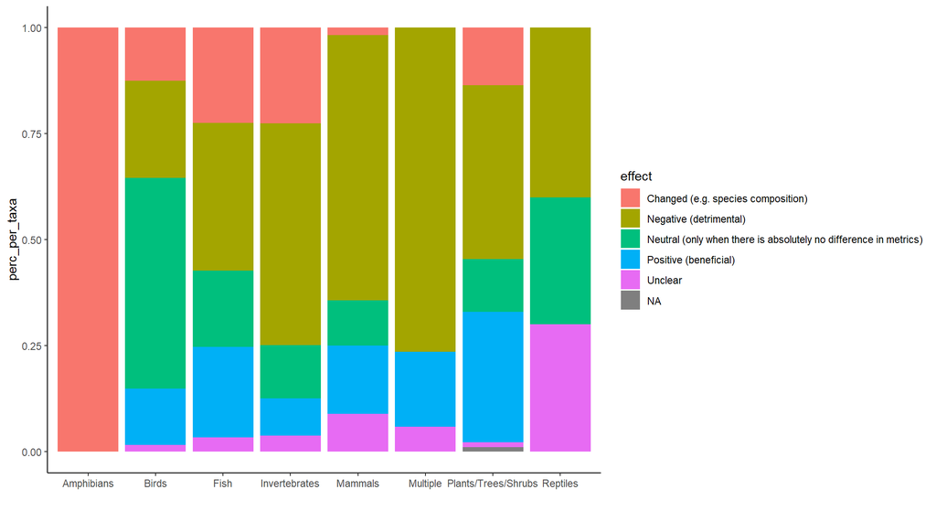

```r
# Stack plot
  quick_plot <- ggplot(a, aes(fill=effect, y=perc_per_taxa, x=taxa)) +
                geom_bar(position="stack", stat="identity") +
                theme(axis.text.x = element_text(angle = 45, hjust = 1)) +
                theme_classic() +
                xlab("")

# save image
  ggsave(filename=paste0(fig.dir,"Figure_Xtra_effects_by_taxa.png"),
         plot=quick_plot, height = 6, width = 11)

# view
  quick_plot
```

Numbers instead of percents

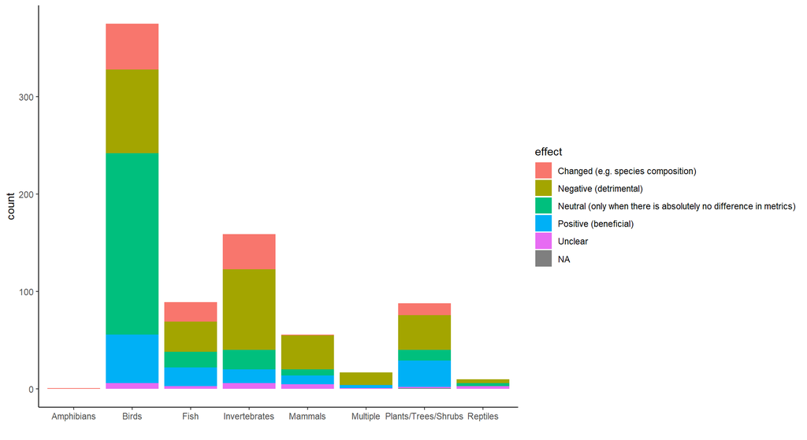

```r
# Stack plot
  quick_plot <- ggplot(a, aes(fill=effect, y=count, x=taxa)) +
                geom_bar(position="stack", stat="identity") +
                theme(axis.text.x = element_text(angle = 45, hjust = 1)) +
                theme_classic() +
                xlab("")

# save image
  ggsave(filename=paste0(fig.dir,"Figure_Xtra_effects_by_taxa2.png"),
         plot=quick_plot, height = 6, width = 11)

# view
  quick_plot
```

# 6. Cleaned survey export

```r
# export
  write.csv(survey3,paste0(dat.dir,'survey3_cleaned.csv'),row.names=FALSE)
```